# Exploratory Data Analysis Report

2023-01-05

## Exploratory Data analysis (EDA)

Analyzing the data sets to summarize their main characteristics of variables, often with visual graphs, without using a statistical model.

### 1. Overview of the data

Understanding the dimensions of the dataset, variable names, overall missing summary and data types of each variables

```r
# Overview of the data
ExpData(data=data,type=1)
# Structure of the data
ExpData(data=data,type=2)
```

**Overview of the data**

| Descriptions | Value |
| --- | --- |
| Sample size (nrow) | 9898 |
| No. of variables (ncol) | 7 |
| No. of numeric/interger variables | 3 |
| No. of factor variables | 4 |
| No. of text variables | 0 |
| No. of logical variables | 0 |
| No. of identifier variables | 0 |
| No. of date variables | 0 |
| No. of zero variance variables (uniform) | 0 |
| %. of variables having complete cases | 100% (7) |

[output cut: 3 more lines]

**Structure of the data**

| Index | Variable_Name | Variable_Type | Sample_n | Missing_Count | Per_of_Missing | No_of_distinct_values |
| --- | --- | --- | --- | --- | --- | --- |
| 1 | salary | numeric | 9898 | 0 | 0 | 9656 |
| 2 | age | integer | 9898 | 0 | 0 | 61 |
| 3 | elevel | factor | 9898 | 0 | 0 | 5 |
| 4 | car | factor | 9898 | 0 | 0 | 20 |
| 5 | zipcode | factor | 9898 | 0 | 0 | 9 |
| 6 | credit | numeric | 9898 | 0 | 0 | 9652 |
| 7 | brand | factor | 9898 | 0 | 0 | 2 |

**Target variable**

Summary of categorical dependent variable

```
##   brand Frequency Descriptions
## 1     0      3744        brand
## 2     1      6154        brand
```

### 2. Summary of numerical variables

Summary of all numerical variables

Summary statistics when dependent variable is categorical **brand**. Summary statistics will be splitted into category level

```r
ExpNumStat(data,by="GA",gp=Target,Qnt=seq(0,1,0.1),MesofShape=2,Outlier=TRUE,round=2)
```

| Vname | Group | TN | nNeg | nZero | nPos | NegInf | PosInf | NA_Value | Per_of_Missing | sum | min | max | mean | median | SD | CV | IQR | Skewness | Kurtosis | 0% | 10% | 20% | 30% | 40% | 50% | 60% | 70% | 80% | 90% | … |
| --- | --- | --- | --- | --- | --- | --- | --- | --- | --- | --- | --- | --- | --- | --- | --- | --- | --- | --- | --- | --- | --- | --- | --- | --- | --- | --- | --- | --- | --- | --- |
| age | brand:All | 9898 | 0 | 0 | 9898 | 0 | 0 | 0 | 0 | 492709 | 20 | 80.0 | 49.78 | 50.00 | 17.60 | 0.35 | 30.00 | 0.01 | -1.20 | 20 | 26.00 | 32.00 | 38.00 | 43.00 | 50.00 | 56.00 | 62.00 | 68.00 | 74.0 | … |
| age | brand:0 | 3744 | 0 | 0 | 3744 | 0 | 0 | 0 | 0 | 185213 | 20 | 80.0 | 49.47 | 50.00 | 17.41 | 0.35 | 30.00 | 0.03 | -1.18 | 20 | 26.00 | 32.00 | 37.00 | 43.00 | 50.00 | 55.00 | 61.00 | 67.00 | 74.0 | … |
| age | brand:1 | 6154 | 0 | 0 | 6154 | 0 | 0 | 0 | 0 | 307496 | 20 | 80.0 | 49.97 | 50.00 | 17.71 | 0.35 | 31.00 | 0.00 | -1.21 | 20 | 25.30 | 32.00 | 38.00 | 44.00 | 50.00 | 56.00 | 62.00 | 69.00 | 74.0 | … |
| credit | brand:All | 9898 | 0 | 119 | 9779 | 0 | 0 | 0 | 0 | 2466343718 | 0 | 500000.0 | 249175.97 | 250607.15 | 145211.57 | 0.58 | 253832.89 | 0.00 | -1.20 | 0 | 48829.00 | 97059.37 | 147069.47 | 199519.43 | 250607.15 | 297365.93 | 348787.96 | 400338.63 | 449382.5 | … |
| credit | brand:0 | 3744 | 0 | 43 | 3701 | 0 | 0 | 0 | 0 | 928950040 | 0 | 500000.0 | 248117.00 | 249105.49 | 145821.65 | 0.59 | 257372.84 | 0.02 | -1.20 | 0 | 47520.98 | 95775.56 | 144702.60 | 197369.43 | 249105.49 | 296178.88 | 348291.19 | 399036.09 | 450505.0 | … |
| credit | brand:1 | 6154 | 0 | 76 | 6078 | 0 | 0 | 0 | 0 | 1537393677 | 0 | 500000.0 | 249820.23 | 251652.13 | 144847.23 | 0.58 | 252193.22 | 0.00 | -1.19 | 0 | 49634.75 | 97442.83 | 148190.89 | 200039.58 | 251652.13 | 298155.66 | 349038.16 | 401173.95 | 449015.3 | … |
| salary | brand:All | 9898 | 0 | 0 | 9898 | 0 | 0 | 0 | 0 | 840051795 | 20000 | 150000.0 | 84870.86 | 84949.74 | 37712.34 | 0.44 | 65079.94 | -0.01 | -1.19 | 20000 | 32494.69 | 45445.54 | 58961.94 | 72263.35 | 84949.74 | 97679.71 | 110855.39 | 124224.12 | 137038.4 | … |
| salary | brand:0 | 3744 | 0 | 0 | 3744 | 0 | 0 | 0 | 0 | 280379288 | 20000 | 130722.4 | 74887.63 | 74858.97 | 25115.62 | 0.34 | 36967.77 | 0.00 | -0.73 | 20000 | 40282.47 | 52342.36 | 60151.63 | 67804.38 | 74858.97 | 82284.71 | 89377.21 | 97136.53 | 109915.3 | … |
| salary | brand:1 | 6154 | 0 | 0 | 6154 | 0 | 0 | 0 | 0 | 559672506 | 20000 | 150000.0 | 90944.51 | 101571.33 | 42501.22 | 0.47 | 82827.46 | -0.28 | -1.40 | 20000 | 29180.77 | 41005.30 | 56688.21 | 81709.18 | 101571.33 | 113637.05 | 125358.38 | 133881.70 | 141847.5 | … |

### 3. Distributions of Numerical variables

- Box plots for all numerical variables vs categorical dependent variable - Bivariate comparision only with categories
  - Quantile-quantile plot(Univariate)
  - Density plot (Univariate)
  - Box plot (Univariate and Bivariate)
  - Scatter plot (Bivariate)

#### Quantile-quantile plot for Numerical variables - Univariate

Quantile-quantile plot for all Numerical variables

```r
ExpOutQQ(data,nlim=4,fname=NULL,Page=c(2,2),sample=sn)
```

```
## $`0`
```

[figure not shown]

#### Density plots for Numerical variables - Univariate

Density plot for all Numerical variables

```
## $`0`
```

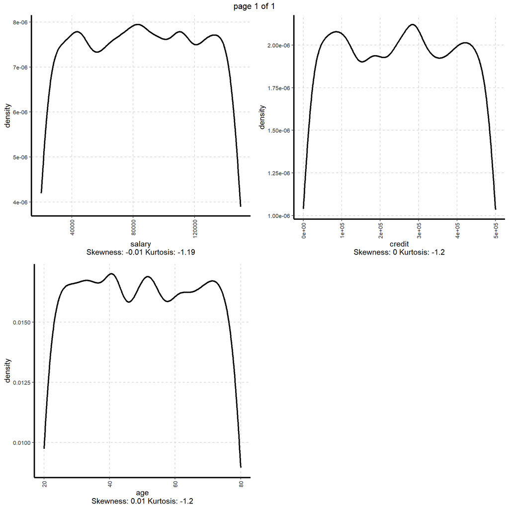

```r
ExpNumViz(data,target=NULL,type=1,Page=c(2,2),theme=theme,sample=sn)
```

#### Scatter plot for all numeric features - Bivariate analysis

```
## $`0`
```

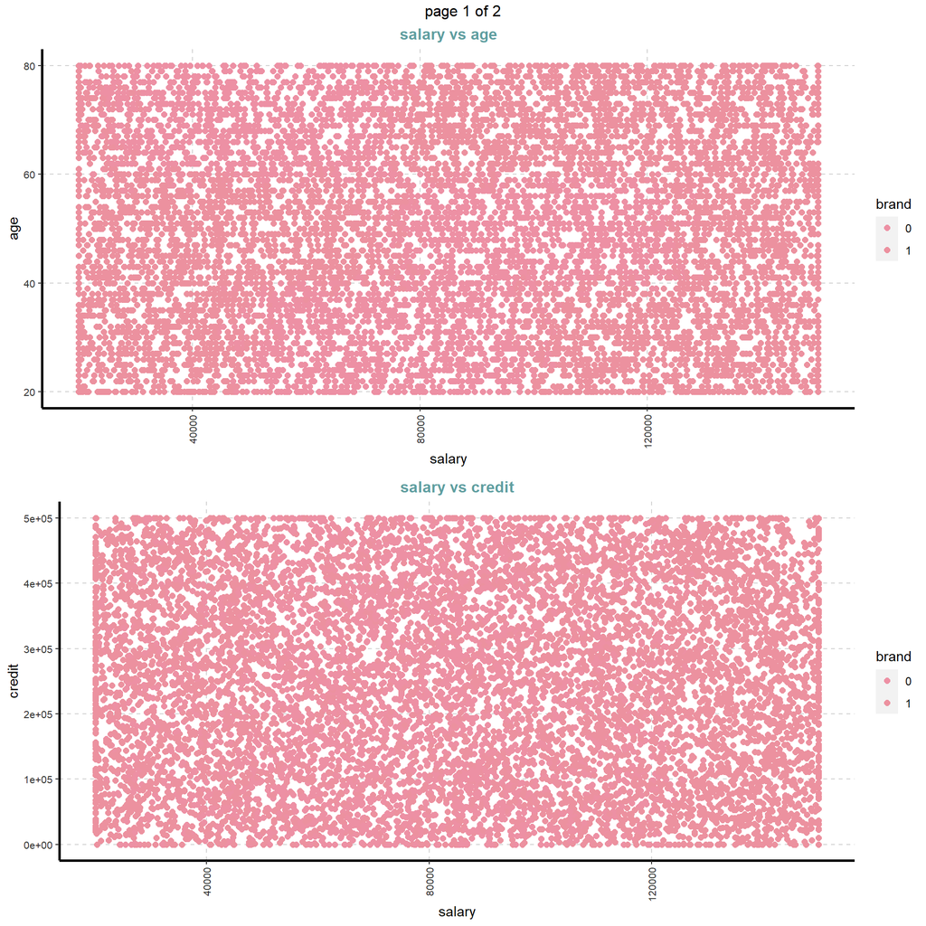

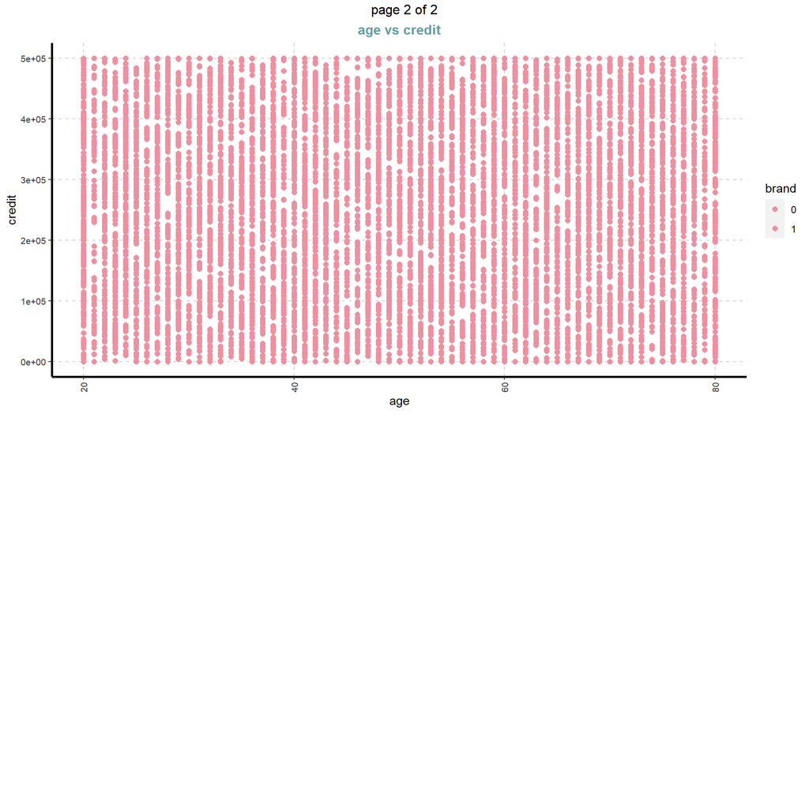

```r
ExpNumViz(data,target=Target,Page=c(2,1),theme=theme,sample=sn,scatter=TRUE)
```

#### Box plots for all numeric features vs categorical dependent variable - Bivariate comparision only with categories

Boxplot for all the numeric attributes by each category of **brand**

```
## $`0`
```

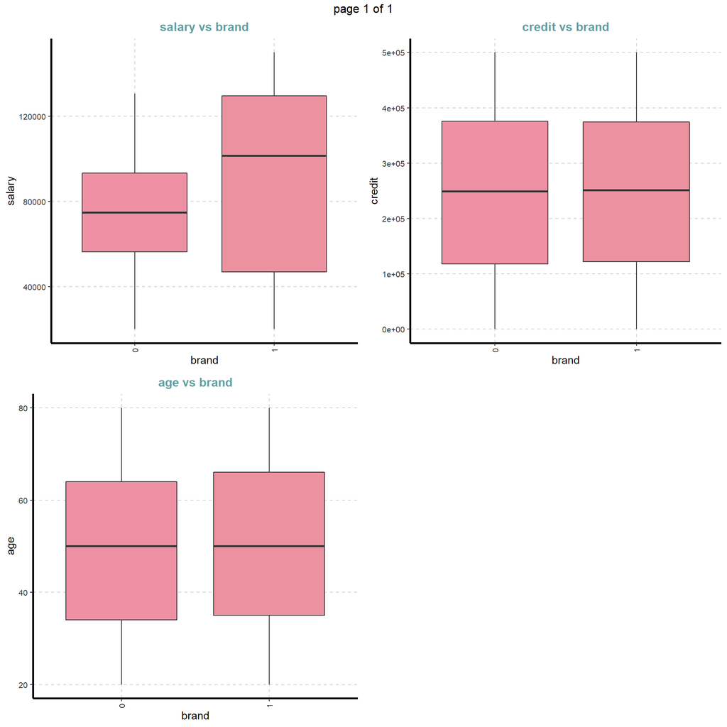

```r
ExpNumViz(data,target=Target,type=2,theme=theme,Page=c(2,2),sample=sn)
```

### 4. Summary of categorical variables

Summary of categorical variable

**Cross tabulation with target variable**

- Custom tables between all categorical independent variables and traget variable **brand**

```r
ExpCTable(data,Target=Target,margin=1,clim=10,nlim=5,round=2,bin=NULL,per=F)
```

| VARIABLE | CATEGORY | brand:0 | brand:1 | TOTAL |
| --- | --- | --- | --- | --- |
| elevel | 0 | 766 | 1286 | 2052 |
| elevel | 1 | 733 | 1215 | 1948 |
| elevel | 2 | 762 | 1221 | 1983 |
| elevel | 3 | 732 | 1215 | 1947 |
| elevel | 4 | 751 | 1217 | 1968 |
| elevel | TOTAL | 3744 | 6154 | 9898 |
| zipcode | 0 | 409 | 676 | 1085 |
| zipcode | 1 | 400 | 653 | 1053 |
| zipcode | 2 | 429 | 683 | 1112 |
| zipcode | 3 | 403 | 677 | 1080 |

[output cut: 6 more lines]

**Information Value**

```r
ExpCatStat(data,Target=Target,Label=label,result = "IV",clim=10,nlim=5,Pclass=Rc)
```

| Variable | Class | Out_1 | Out_0 | TOTAL | Per_1 | Per_0 | Odds | WOE | IV | Ref_1 | Ref_0 | Target |
| --- | --- | --- | --- | --- | --- | --- | --- | --- | --- | --- | --- | --- |
| elevel.1 | 0 | 2052 | 2052 | 4104 | 0.21 | 0.21 | 1 | 0 | 0 | Yes | 0, 1 | brand |
| elevel.2 | 1 | 1948 | 1948 | 3896 | 0.20 | 0.20 | 1 | 0 | 0 | Yes | 0, 1 | brand |
| elevel.3 | 2 | 1983 | 1983 | 3966 | 0.20 | 0.20 | 1 | 0 | 0 | Yes | 0, 1 | brand |
| elevel.4 | 3 | 1947 | 1947 | 3894 | 0.20 | 0.20 | 1 | 0 | 0 | Yes | 0, 1 | brand |
| elevel.5 | 4 | 1968 | 1968 | 3936 | 0.20 | 0.20 | 1 | 0 | 0 | Yes | 0, 1 | brand |
| zipcode.1 | 0 | 1085 | 1085 | 2170 | 0.11 | 0.11 | 1 | 0 | 0 | Yes | 0, 1 | brand |
| zipcode.2 | 1 | 1053 | 1053 | 2106 | 0.11 | 0.11 | 1 | 0 | 0 | Yes | 0, 1 | brand |
| zipcode.3 | 2 | 1112 | 1112 | 2224 | 0.11 | 0.11 | 1 | 0 | 0 | Yes | 0, 1 | brand |
| zipcode.4 | 3 | 1080 | 1080 | 2160 | 0.11 | 0.11 | 1 | 0 | 0 | Yes | 0, 1 | brand |
| zipcode.5 | 4 | 1087 | 1087 | 2174 | 0.11 | 0.11 | 1 | 0 | 0 | Yes | 0, 1 | brand |

[output cut: 34 more lines]

**Statistical test**

```r
ExpCatStat(data,Target=Target,Label=label,result = "Stat",clim=10,nlim=5,Pclass=Rc)
```

| Variable | Target | Unique | Chi-squared | p-value | df | IV Value | Cramers V | Degree of Association | Predictive Power |
| --- | --- | --- | --- | --- | --- | --- | --- | --- | --- |
| elevel | brand | 5 | 0.689 | 0.953 | 4 | 0 | 0.01 | Very Weak | Not Predictive |
| zipcode | brand | 9 | 7.827 | 0.451 | 8 | 0 | 0.03 | Very Weak | Not Predictive |
| salary | brand | 10 | 2384.646 | 0.000 | 9 | 0 | 0.49 | Strong | Not Predictive |
| age | brand | 10 | 10.624 | 0.302 | 9 | 0 | 0.03 | Very Weak | Not Predictive |
| credit | brand | 10 | 3.294 | 0.951 | 9 | 0 | 0.02 | Very Weak | Not Predictive |

**Variable importance based on Information value**

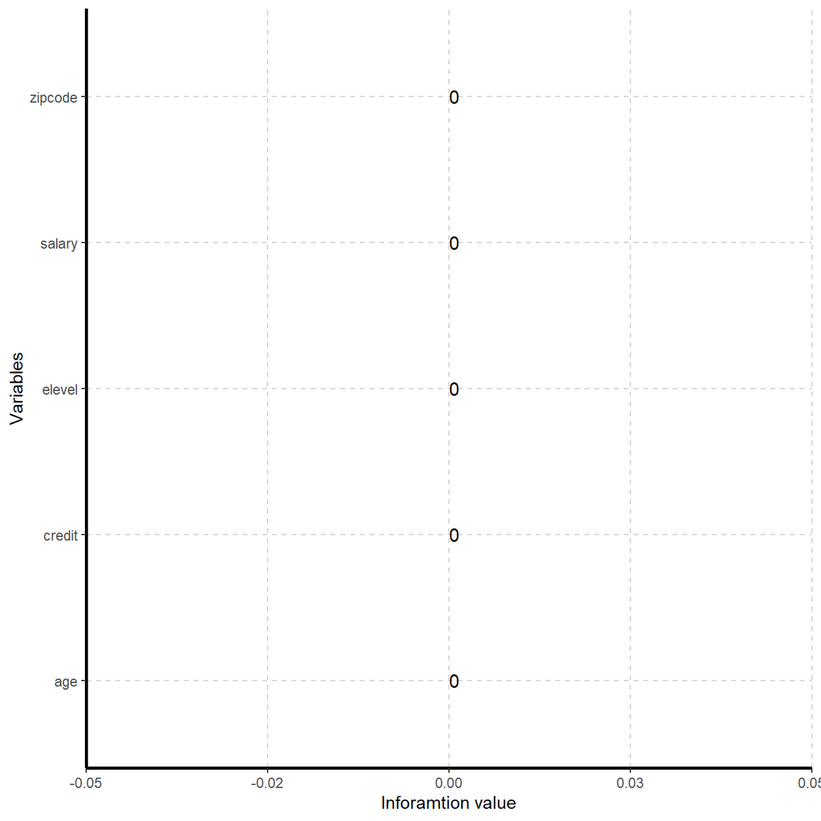

```r
varimp <- ExpCatStat(data,Target=Target,result = "Stat",clim=10,nlim=5,Pclass=Rc,bins=10,plot=TRUE,top=30,Round=2)
```

### 5. Distributions of categorical variables

Graphical representation of all categorical variables

**Bar plots for all categorical variables**

- Bar plot with vertical or horizontal bars for all categorical variables

```
## $`0`
```

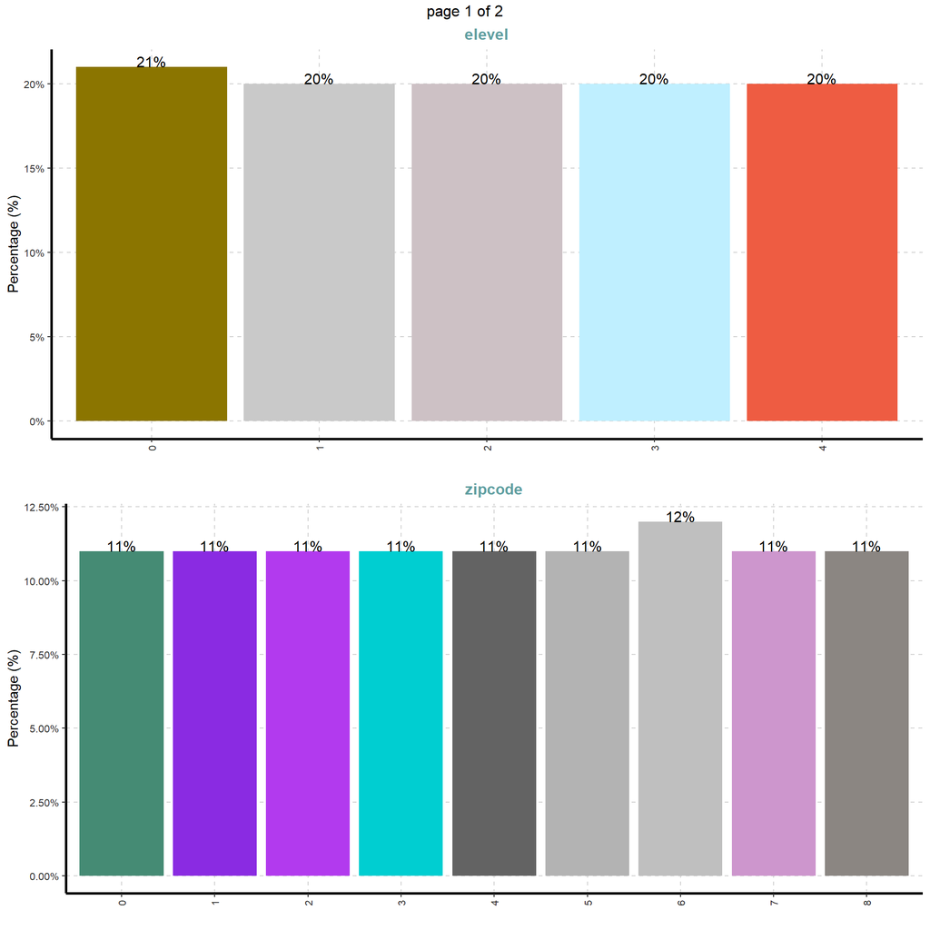

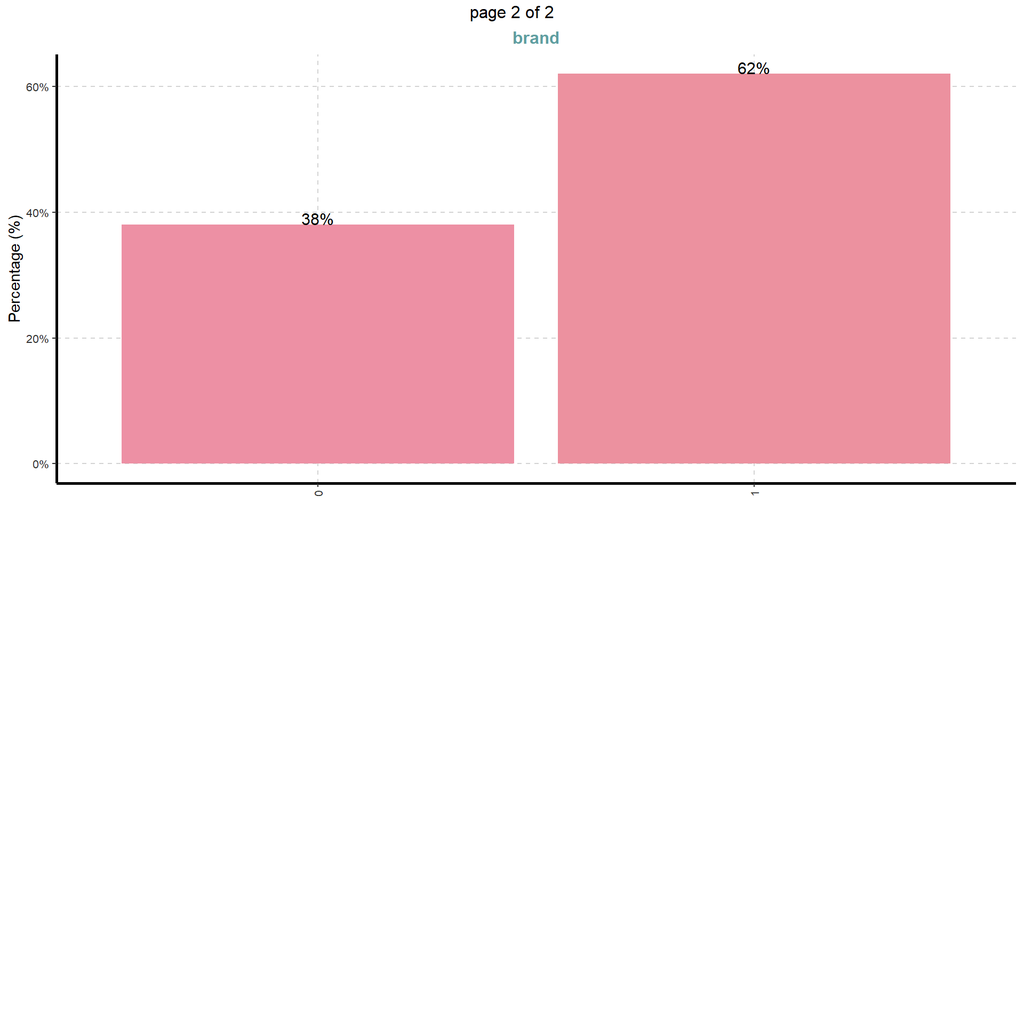

```r
ExpCatViz(data,target=NULL,fname=NULL,clim=10,margin=2,theme=theme,Page = c(2,1),sample=sc)
```

```
## $`0`
```

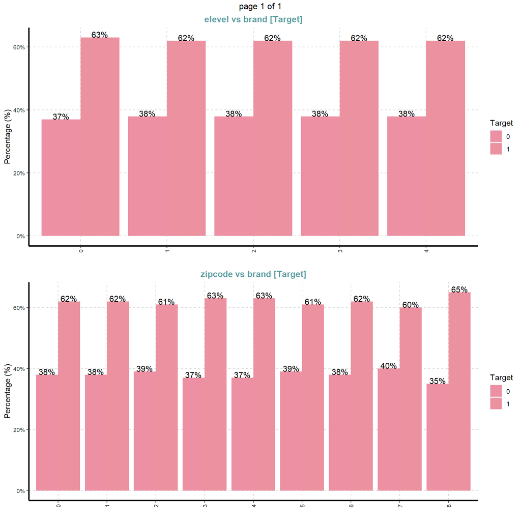

```r
ExpCatViz(data,target=Target,fname=NULL,clim=10,margin=2,theme=theme,Page = c(2,1),sample=sc)
```